# Florida COVID-19 Trajectory

Roy Williams, Gabriel J. Odom, Zoran Bursac, and Mary Jo Trepka

03 November 2021

[figure not shown]

# Disclaimer

Information provided is via open source national data sources and provisional. When information conflicts with local data, local data should be given deference. The information provided is for informational purposes only and is not a substitute for local, state or national reporting of infectious disease. By using this website you agree the information provided herein is to be used for informational purposes only and release the owner from any liability associated with the usage, accuracy, or dissemination of this information. CDC, HHS, and all other national data sources are listed as a subsection of this report.

$~$

# Introduction

$~$

As of 2021-11-03, the most recent number of daily tests reported was **2899** tests. There have now been **42155394** cumulative tests reported overall with a 7-day moving average of **47991** tests reported. The 7-day moving average for test positivity was **3 %**.

The most recent number of reported cases was **1804** with a 7-day moving average of **1702**. There have now been **3654441** reported for the State of Florida.

There are currently **1875** patients hospitalized in Florida with confirmed or suspected COVID-19. **1847** are adult patients and **28** are pediatric patients. There are currently **437** reported patients hospitalized in a staffed ICU bed with confirmed or suspected COVID-19.

**69.3%** of the population are now vaccinated with at least one dose. Of the age 12 and over population, **79.5%** are now vaccinated with at least one dose. In addition, **98.9%** of those 65 and older are now vaccinated with at least one dose.

$~$

# Cases per Day

$~$

## Cases per Day Table

The following table shows the number and 7-day moving average of COVID-19 cases per day for Florida by day.

| Date | Cases | 7-Day Average | Cumulative Cases |
| --- | --- | --- | --- |
| 2021-11-02 | 1,804 | NA | 3,654,441 |
| 2021-11-01 | 2,000 | NA | 3,652,637 |
| 2021-10-31 | 949 | NA | 3,650,637 |
| 2021-10-30 | 945 | 1,702 | 3,649,688 |
| 2021-10-29 | 1,774 | 1,717 | 3,648,743 |
| 2021-10-28 | 2,086 | 1,722 | 3,646,969 |
| 2021-10-27 | 2,359 | 1,722 | 3,644,883 |
| 2021-10-26 | 1,908 | 1,782 | 3,642,524 |
| 2021-10-25 | 2,036 | 1,850 | 3,640,616 |
| 2021-10-24 | 945 | 1,847 | 3,638,580 |
| 2021-10-23 | 1,367 | 1,860 | 3,637,635 |
| 2021-10-22 | 2,248 | 1,968 | 3,636,268 |
| 2021-10-21 | 2,069 | 1,985 | 3,634,020 |
| 2021-10-20 | 2,448 | 2,112 | 3,631,951 |
| 2021-10-19 | 2,661 | 2,132 | 3,629,503 |
| 2021-10-18 | 2,159 | 2,188 | 3,626,842 |
| 2021-10-17 | 1,832 | 2,303 | 3,624,683 |
| 2021-10-16 | 1,510 | 2,446 | 3,622,851 |
| 2021-10-15 | 2,636 | 2,435 | 3,621,341 |
| 2021-10-14 | 2,876 | 2,509 | 3,618,705 |
| 2021-10-13 | 3,447 | 2,514 | 3,615,829 |
| 2021-10-12 | 2,587 | 2,708 | 3,612,382 |
| 2021-10-11 | 2,675 | 2,791 | 3,609,795 |
| 2021-10-10 | 1,868 | 2,941 | 3,607,120 |
| 2021-10-09 | 2,870 | 3,012 | 3,605,252 |
| 2021-10-08 | 3,213 | 3,180 | 3,602,382 |
| 2021-10-07 | 3,930 | 3,321 | 3,599,169 |
| 2021-10-06 | 3,944 | 3,442 | 3,595,239 |
| 2021-10-05 | 3,757 | 3,489 | 3,591,295 |
| 2021-10-04 | 3,665 | 3,673 | 3,587,538 |

[output cut: 581 more lines]

## Cases per Day Graph

The following graph illustrates the case trajectory of COVID-19 in Florida.

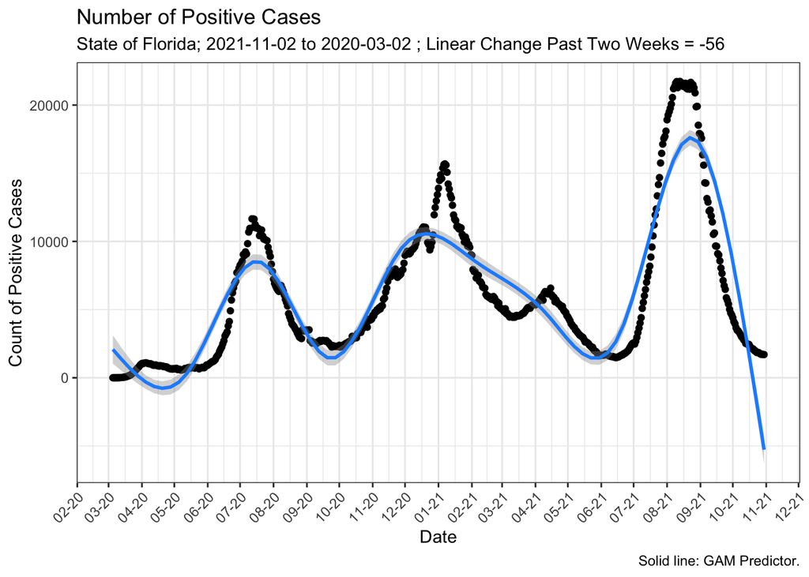

The most recent number of reported cases was **1804**. There have now been **3654441** reported for the State of Florida.

Over the past two weeks, there has been an average decrease of -56 fewer cases reported each day.

$~$

# COVID-19 Testing

$~$

## Testing per Day Table

| Date | Negative | Positive | Inconclusive | Total Tests | Positivity (%) | 7-Day Average Tests | 7-Day Average Positive | 7-Day Average Positivity (%) | Cumulative Tests |
| --- | --- | --- | --- | --- | --- | --- | --- | --- | --- |
| 2021-10-30 | 2,815 | 84 | 0 | 2,899 | 2.90 | NA | NA | NA | 42,155,394 |
| 2021-10-29 | 29,545 | 879 | 13 | 30,437 | 2.89 | NA | NA | NA | 42,152,495 |
| 2021-10-28 | 52,780 | 1,546 | 32 | 54,358 | 2.84 | NA | NA | NA | 42,122,058 |
| 2021-10-27 | 63,456 | 1,915 | 119 | 65,490 | 2.92 | 47,991 | 1,483 | 3 | 42,067,700 |
| 2021-10-26 | 67,439 | 2,087 | 67 | 69,593 | 3.00 | 53,614 | 1,698 | 3 | 42,002,210 |
| 2021-10-25 | 73,919 | 2,318 | 136 | 76,373 | 3.04 | 58,176 | 2,025 | 4 | 41,932,617 |
| 2021-10-24 | 35,141 | 1,553 | 92 | 36,786 | 4.22 | 60,104 | 2,572 | 4 | 41,856,244 |
| 2021-10-23 | 40,643 | 1,586 | 33 | 42,262 | 3.75 | 61,077 | 3,140 | 5 | 41,819,458 |
| 2021-10-22 | 59,127 | 3,168 | 76 | 62,371 | 5.08 | 62,022 | 3,252 | 5 | 41,777,196 |
| 2021-10-21 | 62,402 | 5,376 | 73 | 67,851 | 7.92 | 62,423 | 3,326 | 5 | 41,714,825 |
| 2021-10-20 | 66,337 | 5,892 | 77 | 72,306 | 8.15 | 62,785 | 3,369 | 5 | 41,646,974 |
| 2021-10-19 | 73,218 | 2,873 | 112 | 76,203 | 3.77 | 62,924 | 3,418 | 5 | 41,574,668 |
| 2021-10-18 | 76,265 | 2,836 | 82 | 79,183 | 3.58 | 64,034 | 3,378 | 5 | 41,498,465 |
| 2021-10-17 | 37,420 | 1,850 | 51 | 39,321 | 4.70 | 65,073 | 3,047 | 5 | 41,419,282 |
| 2021-10-16 | 41,254 | 1,932 | 48 | 43,234 | 4.47 | 65,608 | 2,656 | 4 | 41,379,961 |
| 2021-10-15 | 67,133 | 2,885 | 119 | 70,137 | 4.11 | 66,224 | 2,706 | 4 | 41,336,727 |
| 2021-10-14 | 71,913 | 3,059 | 152 | 75,124 | 4.07 | 66,761 | 2,848 | 4 | 41,266,590 |
| 2021-10-13 | 72,789 | 3,159 | 106 | 76,054 | 4.15 | 67,003 | 2,941 | 5 | 41,191,466 |
| 2021-10-12 | 77,164 | 3,218 | 136 | 80,518 | 4.00 | 67,725 | 3,042 | 5 | 41,115,412 |
| 2021-10-11 | 78,922 | 3,835 | 185 | 82,942 | 4.62 | 68,858 | 3,192 | 5 | 41,034,894 |
| 2021-10-10 | 38,461 | 2,502 | 49 | 41,012 | 6.10 | 70,587 | 3,322 | 5 | 40,951,952 |
| 2021-10-09 | 45,574 | 2,637 | 78 | 48,289 | 5.46 | 72,710 | 3,481 | 5 | 40,910,940 |
| 2021-10-08 | 73,983 | 3,937 | 148 | 78,068 | 5.04 | 73,964 | 3,654 | 5 | 40,862,651 |
| 2021-10-07 | 83,094 | 3,966 | 163 | 87,223 | 4.55 | 75,754 | 3,861 | 5 | 40,784,583 |
| 2021-10-06 | 86,471 | 4,274 | 170 | 90,915 | 4.70 | 76,341 | 3,959 | 5 | 40,697,360 |
| 2021-10-05 | 84,760 | 4,426 | 114 | 89,300 | 4.96 | 76,549 | 4,097 | 6 | 40,606,445 |
| 2021-10-04 | 90,008 | 5,282 | 180 | 95,470 | 5.53 | 77,054 | 4,262 | 6 | 40,517,145 |
| 2021-10-03 | 41,827 | 3,192 | 102 | 45,121 | 7.07 | 77,089 | 4,466 | 6 | 40,421,675 |
| 2021-10-02 | 46,021 | 3,605 | 119 | 49,745 | 7.25 | 77,003 | 4,688 | 6 | 40,376,554 |
| 2021-10-01 | 76,321 | 5,091 | 193 | 81,605 | 6.24 | 78,178 | 4,942 | 6 | 40,326,809 |

[output cut: 579 more lines]

## Testing per Day Graph

The following graph illustrates the case trajectory of COVID-19 testing in Florida.

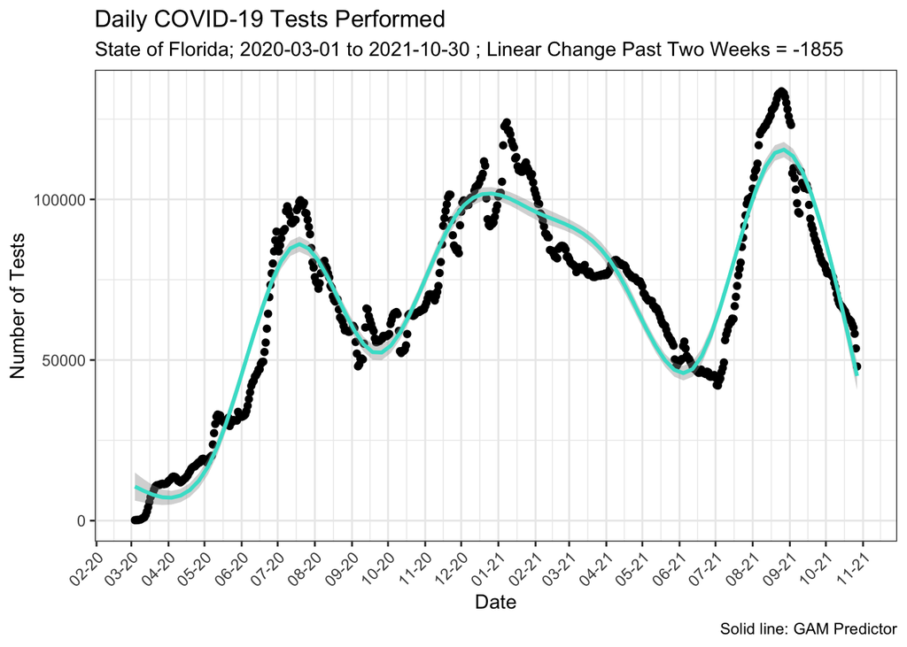

The most recent number of reported tests was **2899**. There have been **42155394** cumulative tests reported since testing began. The 7-day moving average for tests performed was **47991**.

Over the past two weeks, the number of COVID-19 tests performed has decreased by **-1,855** fewer tests reported each day.

$~$

## Postivity Rate Graph

$~$

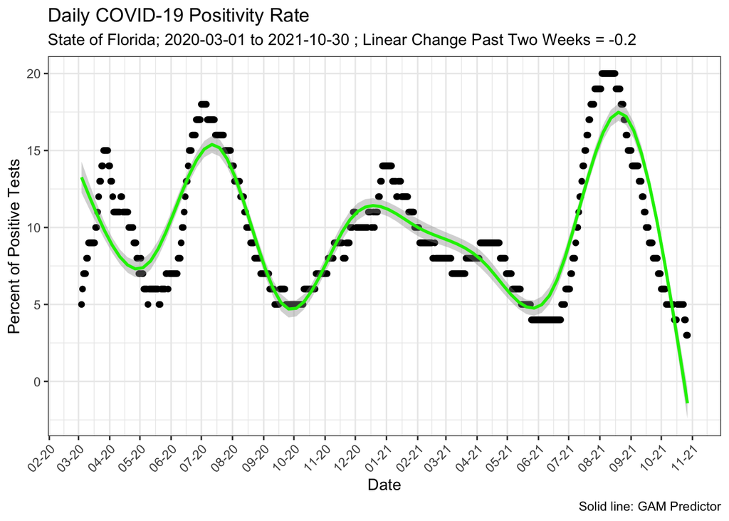

The most recently reported positivity rate was **2.9 %** and the 7-day moving average for case positivity was **3 %**.

Over the past two weeks, the test positivity rate has decreased by **-0.2** fewer percentage points each day.

$~$

# COVID-19 Hospitalizations

$~$

## Hospitalizations per Day Table

The following table shows the daily count of hospitalization census for confirmed and suspected COVID-19 patients by day for adult, pediatric and total patients in the State of Florida. Daily changes and 7-day moving averages are included for comparision.

| Date | Total Patients | Daily Change | 7-Day Average | Adults | Adult 7-Day Average | Pediatric | Pediatric 7-Day Average | Adult ICU | Adult ICU 7-Day Average |
| --- | --- | --- | --- | --- | --- | --- | --- | --- | --- |
| 2021-11-03 | 1,875 | -3 | NA | 1,847 | 28 | NA | NA | 437 | NA |
| 2021-11-02 | 1,878 | -28 | NA | 1,850 | 28 | NA | NA | 437 | NA |
| 2021-11-01 | 1,906 | -1 | NA | 1,879 | 27 | NA | NA | 470 | NA |
| 2021-10-31 | 1,907 | -67 | 1,968 | 1,876 | 31 | 1,935 | 33 | 477 | 478 |
| 2021-10-30 | 1,974 | -99 | 2,017 | 1,938 | 36 | 1,982 | 35 | 491 | 496 |
| 2021-10-29 | 2,073 | -92 | 2,070 | 2,026 | 47 | 2,034 | 36 | 500 | 516 |
| 2021-10-28 | 2,165 | -52 | 2,129 | 2,129 | 36 | 2,091 | 39 | 536 | 532 |
| 2021-10-27 | 2,217 | -33 | 2,184 | 2,179 | 38 | 2,143 | 41 | 560 | 548 |
| 2021-10-26 | 2,250 | -70 | 2,237 | 2,211 | 39 | 2,194 | 43 | 579 | 564 |
| 2021-10-25 | 2,320 | 29 | 2,290 | 2,277 | 43 | 2,246 | 44 | 583 | 580 |
| 2021-10-24 | 2,291 | -54 | 2,341 | 2,242 | 49 | 2,297 | 44 | 586 | 595 |
| 2021-10-23 | 2,345 | -95 | 2,398 | 2,293 | 52 | 2,353 | 45 | 602 | 612 |
| 2021-10-22 | 2,440 | -83 | 2,465 | 2,392 | 48 | 2,419 | 46 | 613 | 634 |
| 2021-10-21 | 2,523 | -94 | 2,542 | 2,482 | 41 | 2,495 | 46 | 641 | 662 |
| 2021-10-20 | 2,617 | -105 | 2,621 | 2,572 | 45 | 2,576 | 46 | 678 | 693 |
| 2021-10-19 | 2,722 | -133 | 2,716 | 2,678 | 44 | 2,670 | 46 | 738 | 723 |
| 2021-10-18 | 2,855 | 7 | 2,807 | 2,809 | 46 | 2,760 | 47 | 777 | 754 |
| 2021-10-17 | 2,848 | -158 | 2,911 | 2,803 | 45 | 2,861 | 50 | 801 | 791 |
| 2021-10-16 | 3,006 | -73 | 3,015 | 2,951 | 55 | 2,962 | 53 | 813 | 826 |
| 2021-10-15 | 3,079 | -168 | 3,122 | 3,026 | 53 | 3,066 | 56 | 829 | 852 |
| 2021-10-14 | 3,247 | -101 | 3,224 | 3,187 | 60 | 3,167 | 57 | 898 | 879 |
| 2021-10-13 | 3,348 | -120 | 3,348 | 3,279 | 69 | 3,281 | 66 | 924 | 906 |
| 2021-10-12 | 3,468 | -106 | 3,448 | 3,407 | 61 | 3,381 | 67 | 922 | 934 |
| 2021-10-11 | 3,574 | -137 | 3,570 | 3,515 | 59 | 3,502 | 69 | 966 | 971 |
| 2021-10-10 | 3,711 | 2 | 3,709 | 3,605 | 106 | 3,637 | 72 | 990 | 1,000 |
| 2021-10-09 | 3,709 | -225 | 3,856 | 3,649 | 60 | 3,782 | 74 | 1,012 | 1,030 |
| 2021-10-08 | 3,934 | -285 | 4,011 | 3,869 | 65 | 3,935 | 77 | 1,084 | 1,069 |
| 2021-10-07 | 4,219 | -158 | 4,156 | 4,134 | 85 | 4,076 | 79 | 1,103 | 1,106 |
| 2021-10-06 | 4,377 | -178 | 4,289 | 4,298 | 79 | 4,212 | 77 | 1,136 | 1,146 |
| 2021-10-05 | 4,555 | -29 | 4,450 | 4,473 | 82 | 4,368 | 82 | 1,192 | 1,190 |

[output cut: 447 more lines]

## Daily Hospital Census

The following graph illustrates the overall census trajectory for individuals hospitalized with COVID-19.

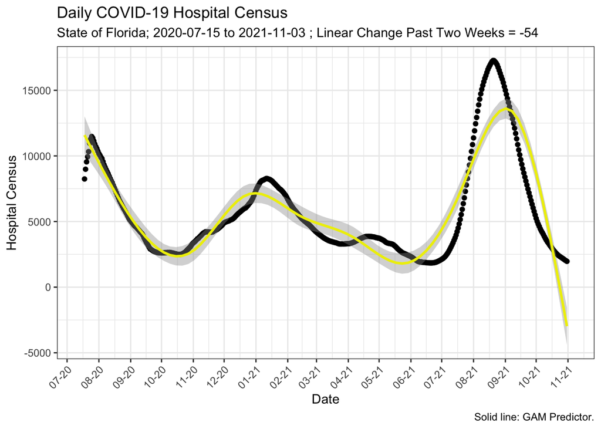

$~$

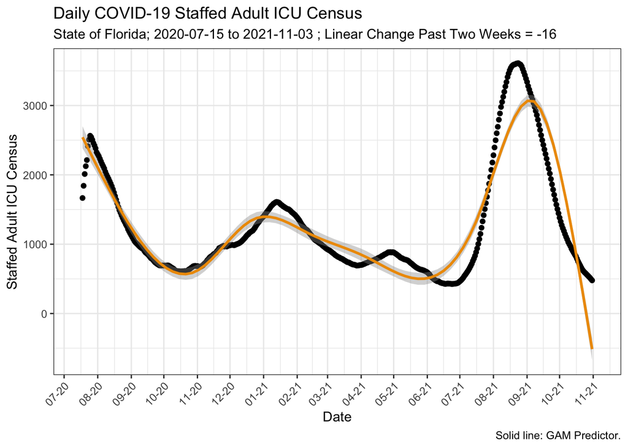

## Daily Hospital Census by Patient Status

The following graph illustrates the overall census trajectory for individuals hospitalized with confirmed or suspected COVID-19 by patient status for adult and pediatric COVID-19 patients.

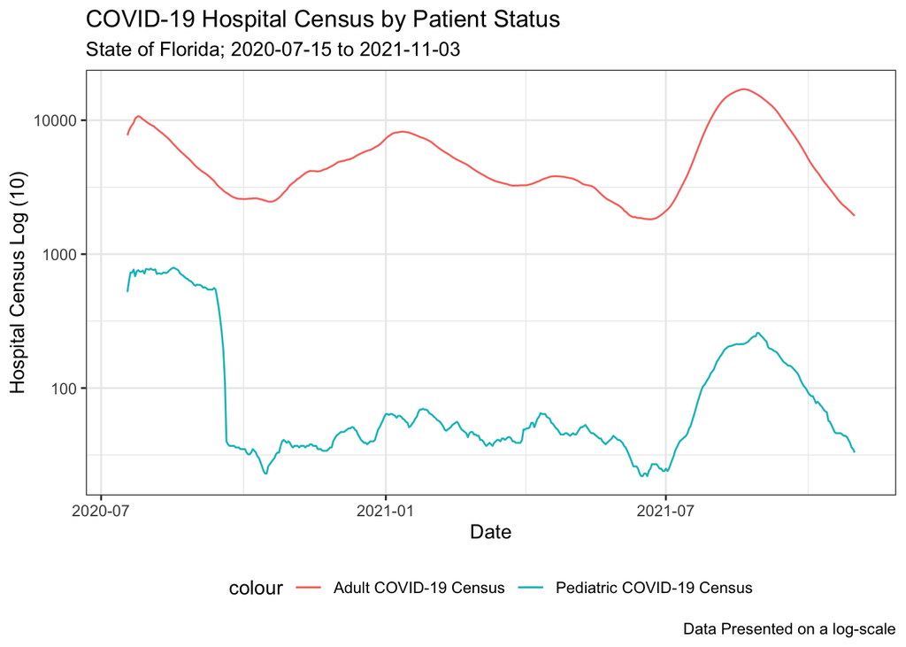

There are currently **1875** patients hospitalized in Florida with confirmed or suspected COVID-19. Of those hospitalized, **1847** are adult patients and **28** are pediatric patients. There are currently **437** reported patients hospitalized in a staffed ICU bed with confirmed or suspected COVID-19.

Over the past two weeks, hospitalizations decreased by **-54** fewer patients with confirmed or suspected COVID-19 reported each day on average. In addition, the number of staffed staffed adult ICU beds with confirmed or suspected COVID-19 patients decrease by **-16** fewer beds per day on average.

$~$

## COVID-19 Vaccination Table

The following table shows the daily and cumulative counts for vaccinations performed by age group. Vaccination includes those with at least one dose of the COVID-19 vaccine.

| Date | Daily First Doses | First Dose 7-Day Average | Cumulative At least First Dose | Cumulative 65+ Vaccinated | Percent of Population Vaccinated | Percentage 12+ Vaccinated | Percentage 65+ Vaccinated |
| --- | --- | --- | --- | --- | --- | --- | --- |
| 2021-11-03 | 12,878 | NA | 14,879,879 | 4,448,603 | 69.3 | 79.5 | 98.9 |
| 2021-11-02 | 8,419 | NA | 14,867,001 | 4,444,880 | 69.2 | 79.5 | 98.8 |
| 2021-11-01 | 11,892 | NA | 14,858,582 | 4,442,663 | 69.2 | 79.4 | 98.8 |
| 2021-10-31 | 16,733 | 13,944 | 14,846,690 | 4,439,474 | 69.1 | 79.4 | 98.7 |
| 2021-10-30 | 16,085 | 14,331 | 14,829,957 | 4,434,412 | 69.0 | 79.3 | 98.6 |
| 2021-10-29 | 13,266 | 14,370 | 14,813,872 | 4,429,028 | 69.0 | 79.2 | 98.5 |
| 2021-10-28 | 18,335 | 13,937 | 14,800,606 | 4,424,295 | 68.9 | 79.1 | 98.4 |
| 2021-10-27 | 15,584 | 13,308 | 14,782,271 | 4,418,231 | 68.8 | 79.0 | 98.2 |
| 2021-10-26 | 8,692 | 12,829 | 14,766,687 | 4,413,999 | 68.8 | 78.9 | 98.1 |
| 2021-10-25 | 8,862 | 18,716 | 14,757,995 | 4,411,294 | 68.7 | 78.9 | 98.1 |
| 2021-10-24 | 12,332 | 16,356 | 14,749,133 | 4,408,783 | 68.7 | 78.8 | 98.0 |
| 2021-10-23 | 12,735 | 16,082 | 14,736,801 | 4,405,853 | 68.6 | 78.8 | 98.0 |
| 2021-10-22 | 54,472 | 16,063 | 14,724,066 | 4,403,083 | 68.6 | 78.7 | 97.9 |
| 2021-10-21 | 1,814 | 16,501 | 14,669,594 | 4,395,142 | 68.3 | 78.4 | 97.7 |
| 2021-10-20 | 13,668 | 17,025 | 14,667,780 | 4,394,535 | 68.3 | 78.4 | 97.7 |
| 2021-10-19 | 8,555 | 17,176 | 14,654,112 | 4,391,961 | 68.2 | 78.3 | 97.7 |
| 2021-10-18 | 11,934 | 11,477 | 14,645,557 | 4,390,687 | 68.2 | 78.3 | 97.6 |
| 2021-10-17 | 15,999 | 13,846 | 14,633,623 | 4,388,621 | 68.1 | 78.2 | 97.6 |
| 2021-10-16 | 13,790 | 13,697 | 14,617,624 | 4,385,609 | 68.1 | 78.1 | 97.5 |
| 2021-10-15 | 14,578 | 13,420 | 14,603,834 | 4,382,711 | 68.0 | 78.1 | 97.5 |
| 2021-10-14 | 18,397 | 13,520 | 14,589,256 | 4,379,570 | 67.9 | 78.0 | 97.4 |
| 2021-10-13 | 12,623 | 12,746 | 14,570,859 | 4,376,319 | 67.8 | 77.9 | 97.3 |
| 2021-10-12 | 6,622 | 13,007 | 14,558,236 | 4,374,059 | 67.8 | 77.8 | 97.3 |
| 2021-10-11 | 12,631 | 14,561 | 14,551,614 | 4,372,908 | 67.8 | 77.8 | 97.2 |
| 2021-10-10 | 10,582 | 13,524 | 14,538,983 | 4,370,685 | 67.7 | 77.7 | 97.2 |
| 2021-10-09 | 15,618 | 13,853 | 14,528,401 | 4,368,370 | 67.6 | 77.7 | 97.1 |
| 2021-10-08 | 25,453 | 14,604 | 14,512,783 | 4,364,680 | 67.6 | 77.6 | 97.1 |
| 2021-10-07 | 11,136 | 18,978 | 14,487,330 | 4,358,259 | 67.5 | 77.4 | 96.9 |
| 2021-10-06 | 14,929 | 17,965 | 14,476,194 | 4,355,503 | 67.4 | 77.4 | 96.8 |
| 2021-10-05 | 11,879 | 17,243 | 14,461,265 | 4,352,428 | 67.3 | 77.3 | 96.8 |

[output cut: 234 more lines]

## COVID-19 Daily Vaccinations Graph

$~$

The following graph illustrates the number of individuals receiving a vaccine dose by date of dose.

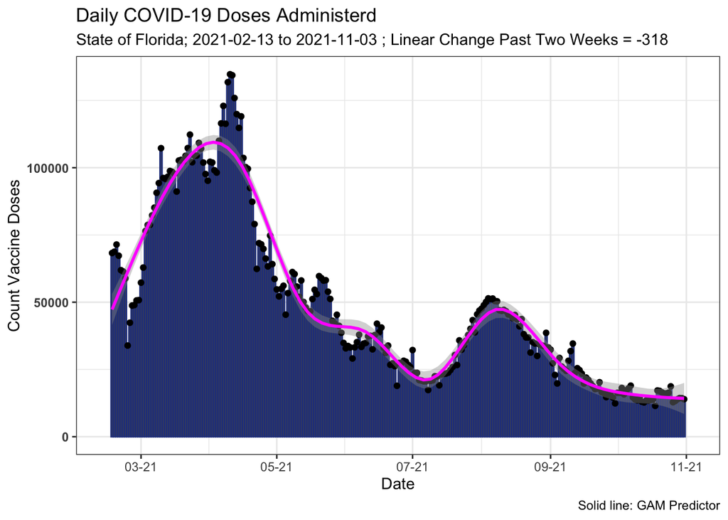

**69.3%** of the population are now vaccinated with at least one dose. Of the age 12 and over population, **79.5%** are now vaccinated with at least one dose. In addition, **98.9%** of those 65 and older are now vaccinated with at least one dose

# COVID-19 Deaths

$~$

## Deaths per Day Table

The following table shows the number and 7-day moving average of COVID-19 deaths per day for Florida by date of death.

| Date | Deaths | 7-Day Average |
| --- | --- | --- |
| 2021-11-02 | 0.0 | NA |
| 2021-11-01 | 2.0 | NA |
| 2021-10-31 | 0.0 | NA |
| 2021-10-30 | 0.0 | 1 |
| 2021-10-29 | 2.0 | 1 |
| 2021-10-28 | 0.0 | 1 |
| 2021-10-27 | 1.0 | 2 |
| 2021-10-26 | 0.0 | 3 |
| 2021-10-25 | 2.0 | 5 |
| 2021-10-24 | 7.0 | 8 |
| 2021-10-23 | 10.0 | 12 |
| 2021-10-22 | 17.0 | 17 |
| 2021-10-21 | 16.0 | 23 |
| 2021-10-20 | 31.0 | 29 |
| 2021-10-19 | 38.0 | 33 |
| 2021-10-18 | 40.0 | 40 |
| 2021-10-17 | 48.0 | 44 |
| 2021-10-16 | 44.0 | 49 |
| 2021-10-15 | 62.0 | 56 |
| 2021-10-14 | 45.0 | 62 |
| 2021-10-13 | 67.0 | 69 |
| 2021-10-12 | 85.0 | 75 |
| 2021-10-11 | 86.0 | 81 |
| 2021-10-10 | 92.0 | 90 |
| 2021-10-09 | 91.0 | 96 |
| 2021-10-08 | 99.0 | 100 |
| 2021-10-07 | 108.0 | 101 |
| 2021-10-06 | 111.0 | 107 |
| 2021-10-05 | 112.0 | 111 |
| 2021-10-04 | 97.0 | 115 |

[output cut: 581 more lines]

$~$

## Deaths per Day Graph

The following graph illustrates the case trajectory of COVID-19 in Florida.

*Nota Bene:* Information by date of death is the most timely and accurate presentation of mortality data. However, as a consequence of the reporting process, information over the past two - three weeks is highly provisional. For this reason, the most recent mortality information over the past two weeks is not included on the following graph and slope calculation. Information reported over the past two-weeks can be found in the above table for reference.

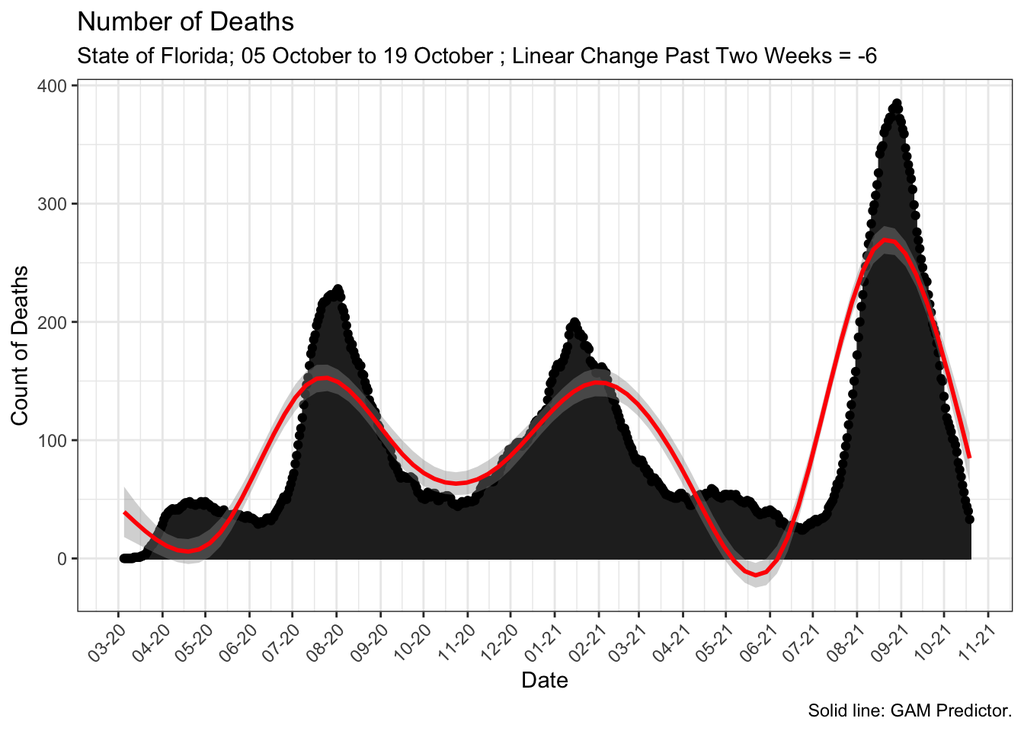

Over the past two weeks of complete data, the number of deaths reported has decreased by an an average of -6 fewer deaths reported each day

$~$

# Data Sources

$~$ Data sources are as follows:

- **COVID-19 Test Results**: COVID-19 Diagnostic Laboratory Testing (PCR Testing) Time Seriers via U.S. Department of Health & Human Services. https://healthdata.gov/dataset/COVID-19-Diagnostic-Laboratory-Testing-PCR-Testing/j8mb-icvb
- **COVID-19 Hospital Census**: COVID-19 Reported Patient Impact and Hospital Capacity by State via U.S. Department of Health & Human Services. https://healthdata.gov/dataset/COVID-19-Reported-Patient-Impact-and-Hospital-Capa/6xf2-c3ie
- **COVID-19 Vaccinations**: COVID-19 Vaccinations in the United States, Jurisdiction via Center for Disease Control. https://data.cdc.gov/Vaccinations/COVID-19-Vaccinations-in-the-United-States-Jurisdi/unsk-b7fc
- **COVID-19 Cases and Deaths**: United States COVID-19 Cases and Deaths by State over Time via Center for Disease Control Case Task Force. https://data.cdc.gov/Case-Surveillance/United-States-COVID-19-Cases-and-Deaths-by-State-o/9mfq-cb36

[GitHub](https://github.com/Rwilli5/MiamiCovidProject/) « Previous Next »